# US wind farm locations

Anna Reynolds

2018-11-15

## Overview

This weeks #TidyTuesday data set contains location and characteristic information about wind turbines in the USA. Some potential questions:

- How do newer installations compare to older turbines?
- Which states/regions have the most wind farms?
- Spread of wind-turbines over time?
- Where is the most missing data?

## Load data

I am trying to get better at using the here package to make the code even more reporoducible.

```r
library(tidyverse)
library(here)
library(ggthemr)
library(knitr)
library(scales)
library(leaflet)
library(DataExplorer)
#Load data
us_wind <- read_csv(here("US_wind.csv"), na = c("missing",-9999,"n/a")) %>% rename(longitude = xlong, latitude = ylat)
kable(head(us_wind))
```

| case_id | faa_ors | faa_asn | usgs_pr_id | t_state | t_county | t_fips | p_name | p_year | p_tnum | p_cap | t_manu | t_model | t_cap | t_hh | t_rd | t_rsa | t_ttlh | t_conf_atr | t_conf_loc | t_img_date | t_img_srce | longitude | latitude |
| --- | --- | --- | --- | --- | --- | --- | --- | --- | --- | --- | --- | --- | --- | --- | --- | --- | --- | --- | --- | --- | --- | --- | --- |
| 3073429 | NA | NA | 4960 | CA | Kern County | 06029 | 251 Wind | 1987 | 194 | 18.43 | Vestas | NA | 95 | NA | NA | NA | NA | 2 | 3 | 1/1/2012 | NAIP | -118.3607 | 35.08378 |
| 3071522 | NA | NA | 4997 | CA | Kern County | 06029 | 251 Wind | 1987 | 194 | 18.43 | Vestas | NA | 95 | NA | NA | NA | NA | 2 | 3 | 1/1/2012 | NAIP | -118.3612 | 35.08151 |
| 3073425 | NA | NA | 4957 | CA | Kern County | 06029 | 251 Wind | 1987 | 194 | 18.43 | Vestas | NA | 95 | NA | NA | NA | NA | 2 | 3 | 1/1/2012 | NAIP | -118.3604 | 35.08471 |
| 3071569 | NA | NA | 5023 | CA | Kern County | 06029 | 251 Wind | 1987 | 194 | 18.43 | Vestas | NA | 95 | NA | NA | NA | NA | 2 | 3 | 7/31/2016 | Digital Globe | -118.3640 | 35.07942 |
| 3005252 | NA | NA | 5768 | CA | Kern County | 06029 | 251 Wind | 1987 | 194 | 18.43 | Vestas | NA | 95 | NA | NA | NA | NA | 2 | 3 | 11/23/2017 | Digital Globe | -118.3543 | 35.08559 |
| 3003862 | NA | NA | 5836 | CA | Kern County | 06029 | 251 Wind | 1987 | 194 | 18.43 | Vestas | NA | 95 | NA | NA | NA | NA | 2 | 3 | 7/31/2017 | Digital Globe | -118.3513 | 35.09140 |

```r
#Set theme
ggthemr(palette = "fresh", set_theme = TRUE)
#Create a report using DataExplorer
#create_report(us_wind)
kable(introduce(us_wind))
```

| rows | columns | discrete_columns | continuous_columns | all_missing_columns | total_missing_values | complete_rows | total_observations | memory_usage |
| --- | --- | --- | --- | --- | --- | --- | --- | --- |
| 58185 | 24 | 10 | 14 | 0 | 93324 | 11793 | 1396440 | 16843296 |

## Analysis/visualization

### Where is the most missing data?

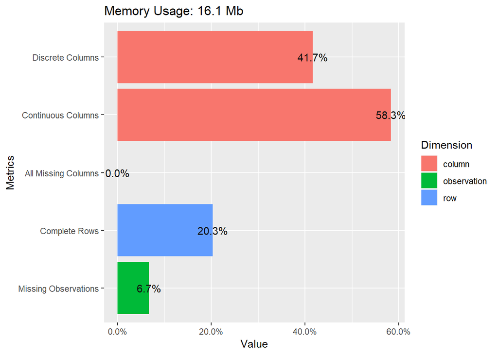

```r
plot_intro(us_wind)
```

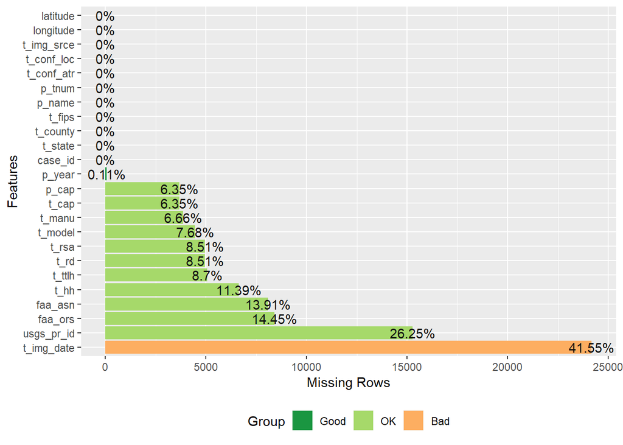

```r
#Which variables have the most missing data?
plot_missing(us_wind)
```

### Remove duplicates

```r
#Number of projects
wind_dedup <- us_wind %>% distinct(t_fips, p_name, .keep_all = TRUE)
kable(introduce(wind_dedup))
```

| rows | columns | discrete_columns | continuous_columns | all_missing_columns | total_missing_values | complete_rows | total_observations | memory_usage |
| --- | --- | --- | --- | --- | --- | --- | --- | --- |
| 1666 | 24 | 10 | 14 | 0 | 3188 | 390 | 39984 | 701880 |

### Which states have the most wind farms?

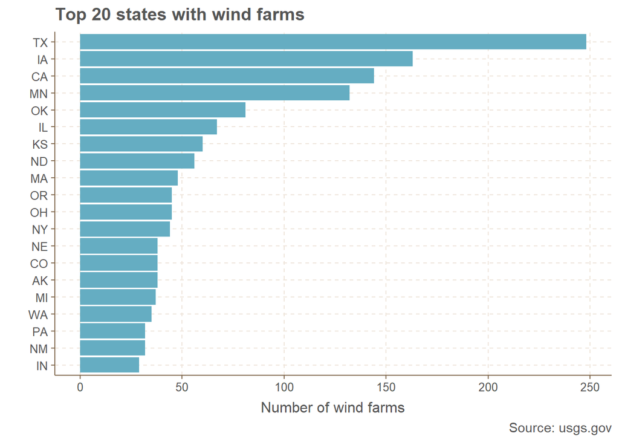

```r
state_20  <- wind_dedup %>% group_by(t_state) %>% summarise(t_state_n = n()) %>% top_n(t_state_n,n=20)
bar <- ggplot(state_20, aes(reorder(t_state, t_state_n), y = t_state_n)) + geom_bar(stat = "identity") + coord_flip() +
  scale_y_continuous(labels = comma_format()) + labs(
  x = " ",
  y = "Number of wind farms",
  title = "Top 20 states with wind farms",
  caption = "Source: usgs.gov")
bar
```

### Where are the wind farms located?

Interactive map

```r
#Filter out Guam
us_wind2 <- wind_dedup %>% filter(t_state != "GU")
leaflet(us_wind2) %>% addTiles() %>%
  addCircleMarkers(
    radius = 4,
    color = "blue",
    stroke = FALSE, fillOpacity = 0.5,
    popup = ~t_county
  )
```

[interactive chart not shown]

Cluster map

```r
leaflet(data = us_wind2) %>%
  setView(-97.3606922, 32.7084083, zoom = 4) %>%
  addTiles() %>% addMarkers(clusterOptions = markerClusterOptions())
```

[interactive chart not shown]

Heat map - number of turbines per farm

```r
library(leaflet.extras)
leaflet(data = us_wind2) %>%
  setView(-97.3606922, 32.7084083, zoom = 4) %>%
  addTiles() %>%
  addHeatmap(
    lng = ~longitude, lat = ~latitude, intensity = ~p_tnum,
    blur = 20, max = 0.05, radius = 15
  )
```

[interactive chart not shown]

### How have the farms changed over time?

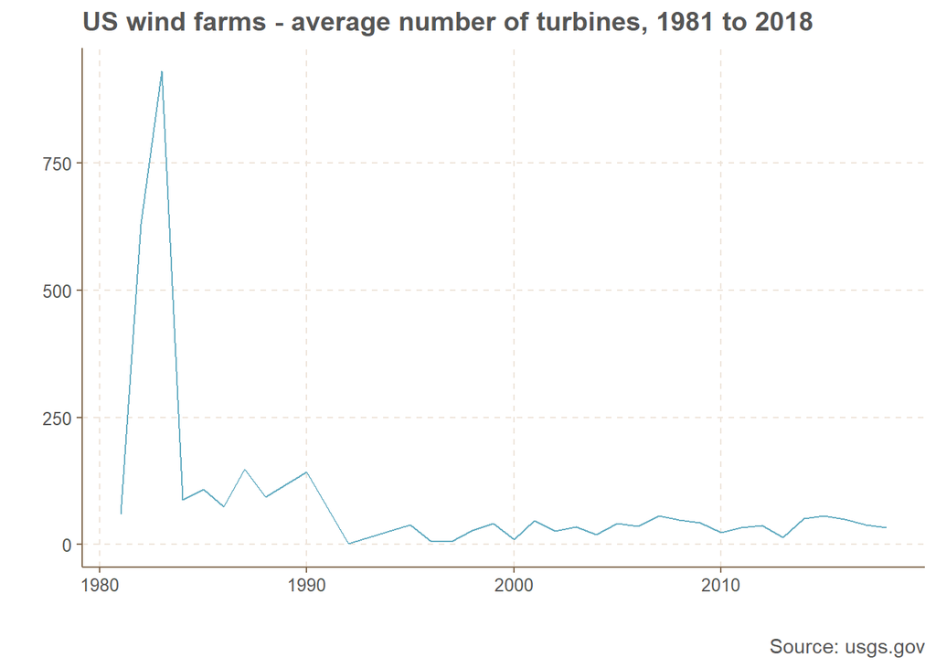

```r
capacity <- wind_dedup %>% group_by(p_year) %>% summarize(avg_capacity = mean(t_cap, na.rm=TRUE))
turbines <- wind_dedup %>% group_by(p_year) %>% summarize(avg_turbines = mean(p_tnum, na.rm = TRUE), range_turbines = IQR(p_tnum))
height <- wind_dedup %>% group_by(p_year) %>% summarize(avg_height = mean(t_ttlh, na.rm = TRUE))

line <- ggplot(turbines, aes(p_year, avg_turbines)) + geom_line() +
  scale_y_continuous(labels = comma_format()) + labs(
  x = " ",
  y = " ",
  title = "US wind farms - average number of turbines, 1981 to 2018",
  caption = "Source: usgs.gov"
  )
line
```

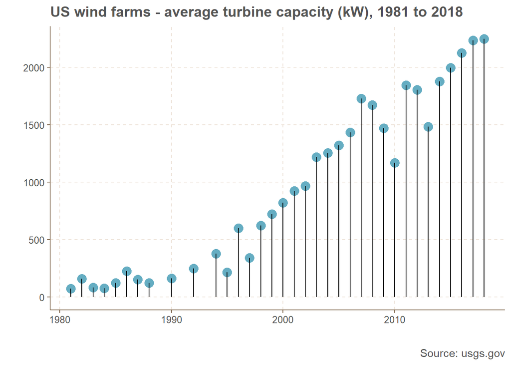

```r
lollipop <- ggplot(capacity, aes(x=p_year, y=avg_capacity)) +
  geom_point(size=4) +
  geom_segment(aes(x=p_year,
                   xend=p_year,
                   y=0,
                   yend=avg_capacity)) +
  labs(x = " ",
  y = " ", title="US wind farms - average turbine capacity (kW), 1981 to 2018",
       caption="Source: usgs.gov")
lollipop
```

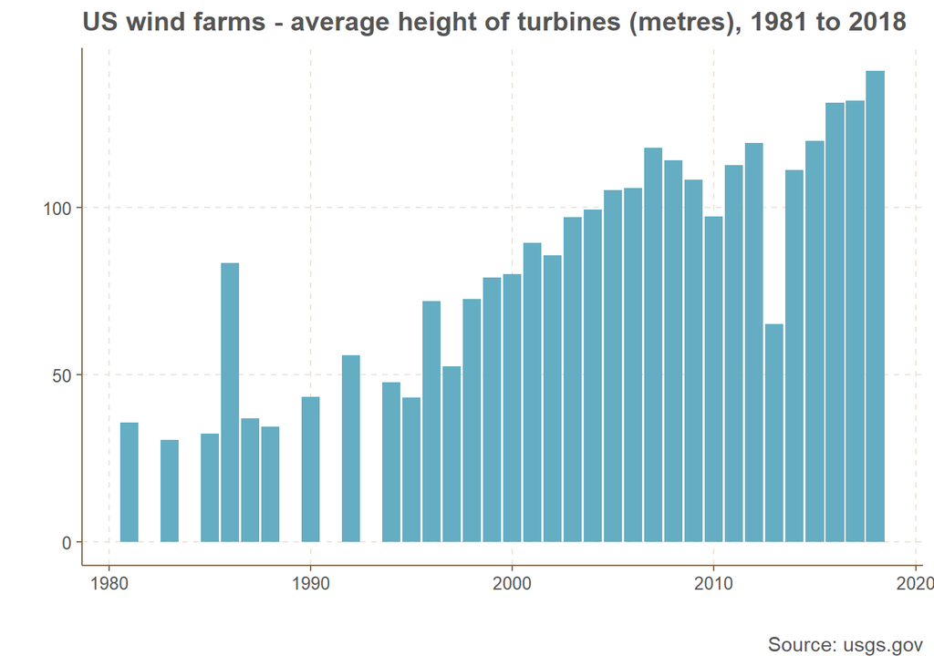

```r
bar <- ggplot(height, aes(p_year, avg_height)) + geom_bar(stat="identity") +
  scale_y_continuous(labels = comma_format()) + labs(
  x = " ",
  y = " ",
  title = "US wind farms - average height of turbines (metres), 1981 to 2018",
  caption = "Source: usgs.gov"
  )
bar
```

### Do taller turbines result in higher capacity?

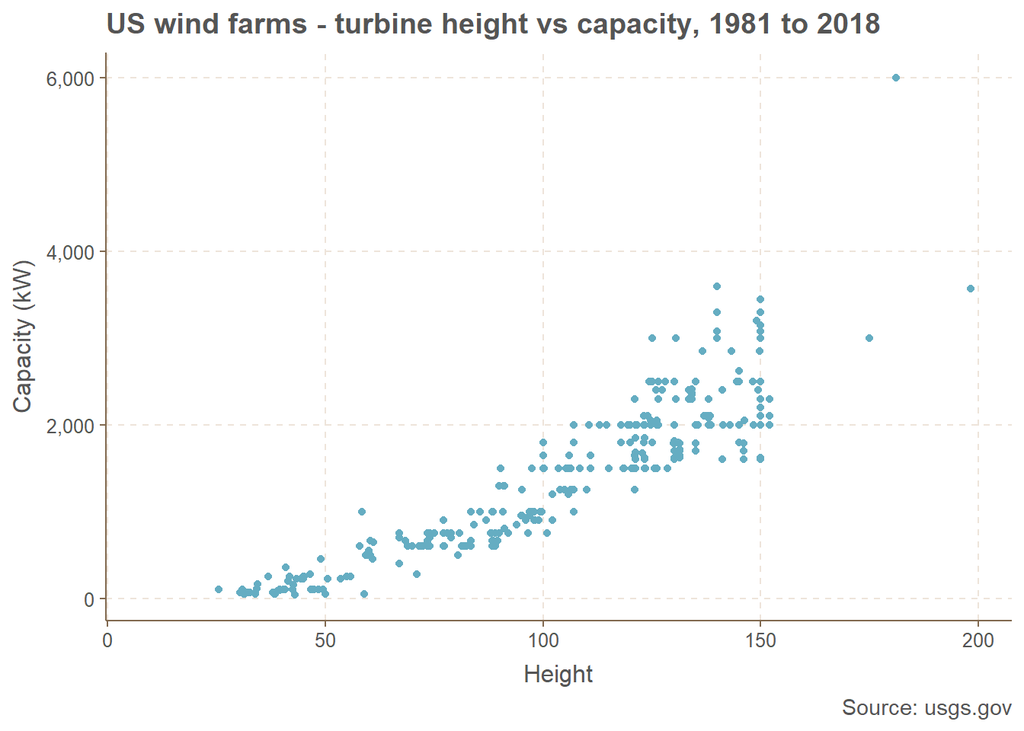

```r
scatter <- ggplot(wind_dedup, aes(t_ttlh, t_cap)) + geom_point() +
  scale_y_continuous(labels = comma_format()) + labs(
  x = "Height",
  y = "Capacity (kW)",
  title = "US wind farms - turbine height vs capacity, 1981 to 2018",
  caption = "Source: usgs.gov"
  )
scatter
```

### How has the establishment of wind farms changed over time?

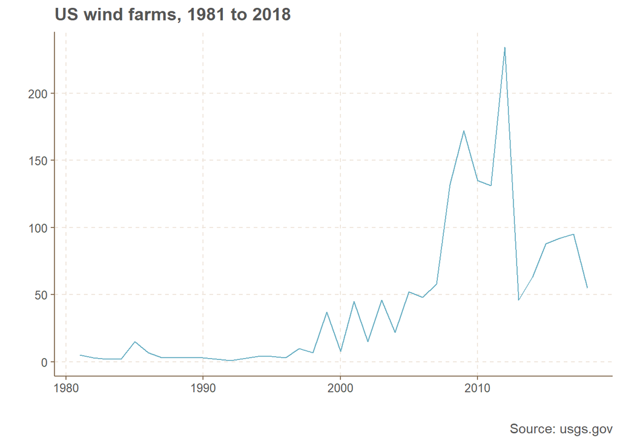

```r
wind_date <- wind_dedup %>% group_by(p_year) %>% summarise(n()) %>% rename(count = `n()`)
line3 <- ggplot(wind_date, aes(p_year, count)) + geom_line() +
  scale_y_continuous(labels = comma_format()) + labs(
  x = " ",
  y = " ",
  title = "US wind farms, 1981 to 2018",
  caption = "Source: usgs.gov"
  )
line3
```

## Results

- 6.7% of the data were missing and the t_img_date variable had the most missing data
- Texas, Iowa and California have the most wind farms
- The average number of turbines per project has declined over time
- The average turbine capacity (kW) has increased over time but there is lots of missing data
- The average height of the turbines has increased over time
- The higher the turbine the greater the capacity
- The number of wind farms has increased since around 2000, and reached a peak in 2012

## Package citations

Boxuan Cui (2018). DataExplorer: Data Explorer. R package version 0.7.0. https://CRAN.R-project.org/package=DataExplorer

Ciaran Tobin (NA). ggthemr: Themes for ggplot2. R package version 1.1.0.

Hadley Wickham (2017). tidyverse: Easily Install and Load the ‘Tidyverse’. R package version 1.2.1. https://CRAN.R-project.org/package=tidyverse

Hadley Wickham (2018). stringr: Simple, Consistent Wrappers for Common String Operations. R package version 1.3.0. https://CRAN.R-project.org/package=stringr

Yihui Xie (2018). knitr: A General-Purpose Package for Dynamic Report Generation in R. R package version 1.20.

Joe Cheng, Bhaskar Karambelkar and Yihui Xie (2018). leaflet: Create Interactive Web Maps with the JavaScript ‘Leaflet’ Library. R package version 2.0.1. https://CRAN.R-project.org/package=leaflet

Bhaskar Karambelkar and Barret Schloerke (2018). leaflet.extras: Extra Functionality for ‘leaflet’ Package. R package version 1.0.0. https://CRAN.R-project.org/package=leaflet.extras